# Quamichan Lake

[Quamichan Lake (E207466)](https://governmentofbc.maps.arcgis.com/apps/MapSeries/index.html?appid=a5ffb1bcffad4407b387292f2e55899f) is located at QUAMICHAN LAKE; CENTRE. Report generated: November 25, 2026.

The plot below shows the sampling history at this site. Composite samples are indicated by a vertical line connecting the uppermost and lowermost sampling depths. Triangles (▲) indicate epilimnion (upper layer) samples; solid circles (●) indicate hypolimnion (bottom layer) samples. For lakes less than 10 m deep, a single sample 1 m below the surface represents the epilimnion and one 1 m off the bottom represents the hypolimnion.

To read more about the B.C. Lakes Monitoring Network (BCLMN) go [here](https://www2.gov.bc.ca/gov/content?id=2493EFF1E42747E1904540DA4D2CF9DD).

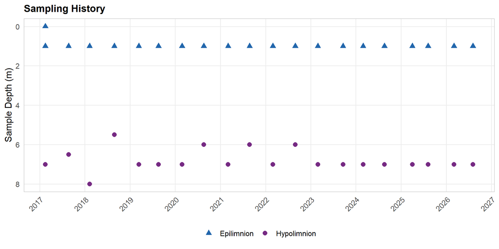

Sampling dates and depth ranges

### Water Quality Trend Summary

The table below gives an at-a-glance summary of every parameter analysed at this site: whether a statistically significant trend (p < 0.05) was detected in each depth/season group, and the applicable BC Aquatic Life guideline. Click a row’s parameter name in the tabs below to see the full plot and history.

**Summary table of trend results**

| Category | Parameter | Epilimnion Spring | Epilimnion Summer | Hypolimnion Spring | Hypolimnion Summer | Guideline |
| --- | --- | --- | --- | --- | --- | --- |
| Field | **Dissolved Oxygen-Field (fl. conc.)** | ▼ 3.3%/yr | — no trend | n/a | n/a | ≥ 8 mg/L |
| Field | **Extinction Depth (len.)** | — no trend | — no trend | n/a | n/a | — |
| Field | **Specific Conductivity-Field (elec. cond.)** | ▲ 1.7%/yr | ▲ 1.3%/yr | n/a | n/a | — |
| Field | **Temperature-Field (temp.)** | — no trend | — no trend | n/a | n/a | — |
| Field | **pH-Field (acidity)** | — no trend | — no trend | n/a | n/a | — |
| General | **Carbon Dissolved Organic (fl. conc.)** | — no trend | — no trend | — no trend | — no trend | — |
| General | **Carbon Total Organic (fl. conc.)** | — no trend | — no trend | — no trend | — no trend | — |
| General | **Chlorophyll A (fl. conc.)** | — no trend | ▲ 15.6%/yr | n/a | n/a | — |
| General | **Specific Conductance (elec. cond.)** | ▲ 1.8%/yr | — no trend | — no trend | — no trend | — |
| General | **Turbidity (turb.)** | ▼ 4.4%/yr | — no trend | — no trend | — no trend | — |
| General | **pH (acidity)** | — no trend | — no trend | — no trend | — no trend | — |
| Major Ions | **Chloride Dissolved (fl. conc.)** | — no trend | — no trend | ▲ 1.6%/yr | — no trend | ≤ 150 mg/L |
| Major Ions | **Hardness Total (Total) (fl. conc.)** | — no trend | — no trend | — no trend | — no trend | — |
| Major Ions | **Sulfate Dissolved (fl. conc.)** | — no trend | ▲ 1.7%/yr | ▲ 1.2%/yr | — no trend | — |
| Nutrients | **Nitrate (NO3) Dissolved (fl. conc.)** | — no trend | — no trend | — no trend | — no trend | ≤ 3 mg/L |
| Nutrients | **Nitrate(NO3) + Nitrite(NO2) Dissolved (fl. conc.)** | — no trend | — no trend | — no trend | — no trend | — |
| Nutrients | **Nitrogen - Nitrite Dissolved (NO2) (fl. conc.)** | ▲ 10.6%/yr | — no trend | ▲ 8.4%/yr | — no trend | — |
| Nutrients | **Nitrogen Ammonia Total (fl. conc.)** | — no trend | ▼ 36.9%/yr | — no trend | — no trend | — |
| Nutrients | **Nitrogen Kjel.Tot(N) (fl. conc.)** | — no trend | — no trend | — no trend | — no trend | — |
| Nutrients | **Nitrogen Organic-Total (fl. conc.)** | — no trend | — no trend | — no trend | — no trend | — |
| Nutrients | **Nitrogen Total (fl. conc.)** | — no trend | — no trend | — no trend | — no trend | — |
| Nutrients | **Phosphorus Ort.Dis-P (fl. conc.)** | ▼ 11.6%/yr | ▼ 24.9%/yr | ▼ 12.9%/yr | — no trend | — |
| Nutrients | **Phosphorus Total (fl. conc.)** | ▼ 9.0%/yr | ▼ 9.0%/yr | ▼ 10.6%/yr | — no trend | ≤ 15 ug/L |
| Nutrients | **Phosphorus Total Dissolved (fl. conc.)** | ▼ 9.9%/yr | ▼ 19.3%/yr | ▼ 12.5%/yr | — no trend | — |
| Nutrients | **Silica Reactive Diss (fl. conc.)** | — no trend | — no trend | — no trend | — no trend | — |
| Metals - Total | **Aluminum Total (fl. conc.)** | — no trend | — no trend | — no trend | — no trend | — |
| Metals - Total | **Antimony Total (fl. conc.)** | ▼ 4.6%/yr | ▼ 5.8%/yr | ▼ 4.5%/yr | — no trend | ≤ 74 ug/L |
| Metals - Total | **Arsenic Total (fl. conc.)** | ▼ 5.0%/yr | ▼ 5.6%/yr | ▼ 6.1%/yr | ▼ 6.1%/yr | ≤ 5 ug/L |
| Metals - Total | **Barium Total (fl. conc.)** | ▲ 2.6%/yr | — no trend | ▲ 2.2%/yr | — no trend | ≤ 1 mg/L |
| Metals - Total | **Beryllium Total (fl. conc.)** | — no trend | — no trend | — no trend | — no trend | ≤ 0.13 ug/L |
| Metals - Total | **Bismuth Total (fl. conc.)** | — no trend | — no trend | — no trend | — no trend | — |
| Metals - Total | **Boron Total (fl. conc.)** | — no trend | — no trend | — no trend | — no trend | ≤ 1.2 mg/L |
| Metals - Total | **Cadmium Total (fl. conc.)** | — no trend | — no trend | — no trend | — no trend | — |
| Metals - Total | **Calcium Total (fl. conc.)** | — no trend | — no trend | — no trend | — no trend | — |
| Metals - Total | **Chromium Total (fl. conc.)** | — no trend | — no trend | — no trend | — no trend | — |
| Metals - Total | **Cobalt Total (fl. conc.)** | — no trend | — no trend | — no trend | ▲ 9.5%/yr | — |
| Metals - Total | **Copper Total (fl. conc.)** | — no trend | — no trend | — no trend | — no trend | — |
| Metals - Total | **Iron Total (fl. conc.)** | — no trend | — no trend | — no trend | — no trend | — |
| Metals - Total | **Lead Total (fl. conc.)** | ▼ 17.2%/yr | — no trend | ▼ 12.6%/yr | — no trend | — |
| Metals - Total | **Lithium Total (fl. conc.)** | — no trend | — no trend | — no trend | — no trend | — |
| Metals - Total | **Magnesium Total (fl. conc.)** | — no trend | — no trend | — no trend | — no trend | — |
| Metals - Total | **Manganese Total (fl. conc.)** | — no trend | ▼ 8.2%/yr | — no trend | — no trend | — |
| Metals - Total | **Molybdenum Total (fl. conc.)** | ▼ 6.1%/yr | ▼ 7.0%/yr | ▼ 5.6%/yr | — no trend | ≤ 7.6 mg/L |
| Metals - Total | **Nickel Total (fl. conc.)** | — no trend | — no trend | — no trend | — no trend | — |
| Metals - Total | **Potassium Total (fl. conc.)** | — no trend | — no trend | — no trend | — no trend | — |
| Metals - Total | **Selenium Total (fl. conc.)** | — no trend | — no trend | — no trend | — no trend | ≤ 2 ug/L |
| Metals - Total | **Silicon Total (fl. conc.)** | — no trend | — no trend | — no trend | — no trend | — |
| Metals - Total | **Silver Total (fl. conc.)** | — no trend | — no trend | — no trend | — no trend | ≤ 0.12 ug/L |
| Metals - Total | **Sodium Total (fl. conc.)** | — no trend | — no trend | — no trend | — no trend | — |
| Metals - Total | **Strontium Total (fl. conc.)** | ▲ 1.8%/yr | — no trend | ▲ 1.7%/yr | — no trend | — |
| Metals - Total | **Thallium Total (fl. conc.)** | — no trend | — no trend | — no trend | — no trend | ≤ 0.03 ug/L |
| Metals - Total | **Tin Total (fl. conc.)** | — no trend | — no trend | — no trend | — no trend | — |
| Metals - Total | **Uranium Total (fl. conc.)** | — no trend | — no trend | — no trend | — no trend | ≤ 7.5 ug/L |
| Metals - Total | **Vanadium Total (fl. conc.)** | ▼ 8.4%/yr | ▼ 3.5%/yr | ▼ 9.8%/yr | — no trend | ≤ 60 ug/L |
| Metals - Total | **Zinc Total (fl. conc.)** | — no trend | — no trend | — no trend | — no trend | — |

n/a = fewer than 3 samples (or none) in that depth/season group. — no trend = no statistically significant trend, or more than 50% of results were non-detects. Badge colors indicate the *direction* of a detected trend only, not whether that direction is good or bad for water quality.

### Monitoring Results and Trends

Each observation is shown as a black dot in the scatter plots below. Where a statistically significant trend is detected (p < 0.05 with at least 50% of observations above the detection limit), a trend line with 95% confidence bands is displayed and a coloured trend badge is shown on the plot giving the direction and magnitude of the trend. Open orange triangles (▽) indicate non-detects and are plotted at the detection limit.

If a simple water quality guideline (that is one independent of other parameters) applies and measurements are within that guideline a green check box will display showing the guideline value, conversely if a guideline has been exceeded a yellow warning box will be displayed.

Raw data: [EnMoDS Data Search and Download](https://enmodswr.nrs.gov.bc.ca/) | [Water Quality Guidelines](https://www2.gov.bc.ca/gov/content?id=044DD64C7E24415D83D07430964113C9)

#### **Field**

##### Dissolved Oxygen-Field (fl. conc.)

✓

[BC Aquatic Life Guideline](https://www2.gov.bc.ca/gov/content/environment/air-land-water/water/water-quality/water-quality-guidelines/approved-water-quality-guidelines) · Long-term chronic (Lower Limit) Aquatic Life - Freshwater

≥8 mg/L

All Life Stages Other than Buried Embryo / Alevin

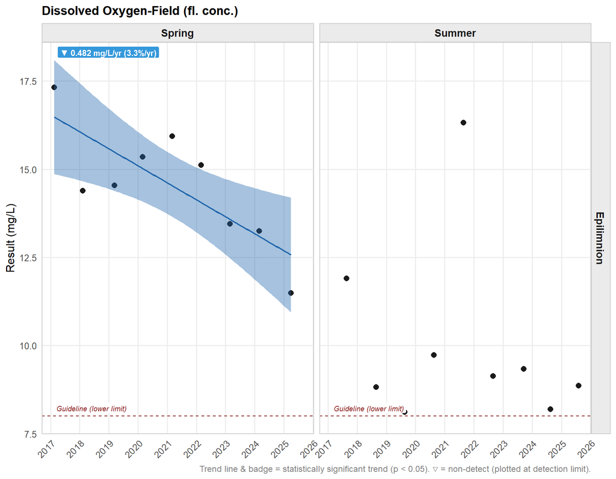

**▶ Summary Statistics Table**

**Quamichan Lake**

Dissolved Oxygen-Field (fl. conc.) (mg/L)

| N | Min<sup>1</sup> | 10th %ile | Median | Mean | 90th %ile | Max |
| --- | --- | --- | --- | --- | --- | --- |
| Epilimnion — Summer |  |  |  |  |  |  |
| 9 | 8.11 | 8.17 | 9.13 | 10 | 12.8 | 16.3 |
| Epilimnion — Spring |  |  |  |  |  |  |
| 9 | 11.5 | 12.9 | 14.5 | 14.5 | 16.2 | 17.3 |

<sup>1</sup> < indicates non-detect; value shown is the detection limit.

##### Extinction Depth (len.)

—

No simple [BC Aquatic Life Guideline](https://www2.gov.bc.ca/gov/content?id=044DD64C7E24415D83D07430964113C9) available for this parameter

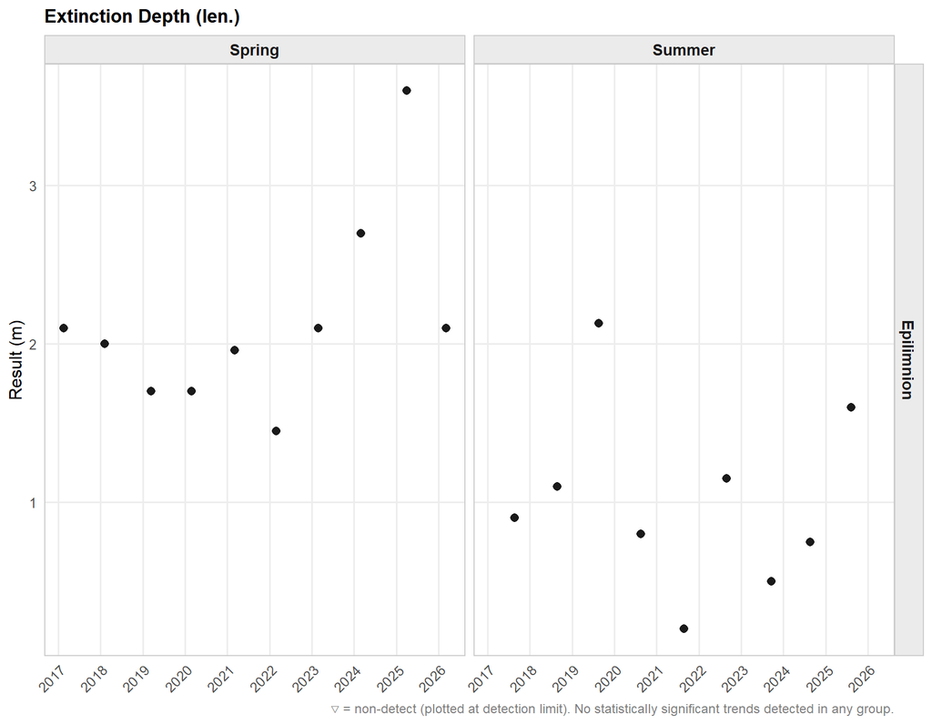

**▶ Summary Statistics Table**

**Quamichan Lake**

Extinction Depth (len.) (m)

[output not shown]

<sup>1</sup> < indicates non-detect; value shown is the detection limit.

##### pH-Field (acidity)

—

No simple [BC Aquatic Life Guideline](https://www2.gov.bc.ca/gov/content?id=044DD64C7E24415D83D07430964113C9) available for this parameter

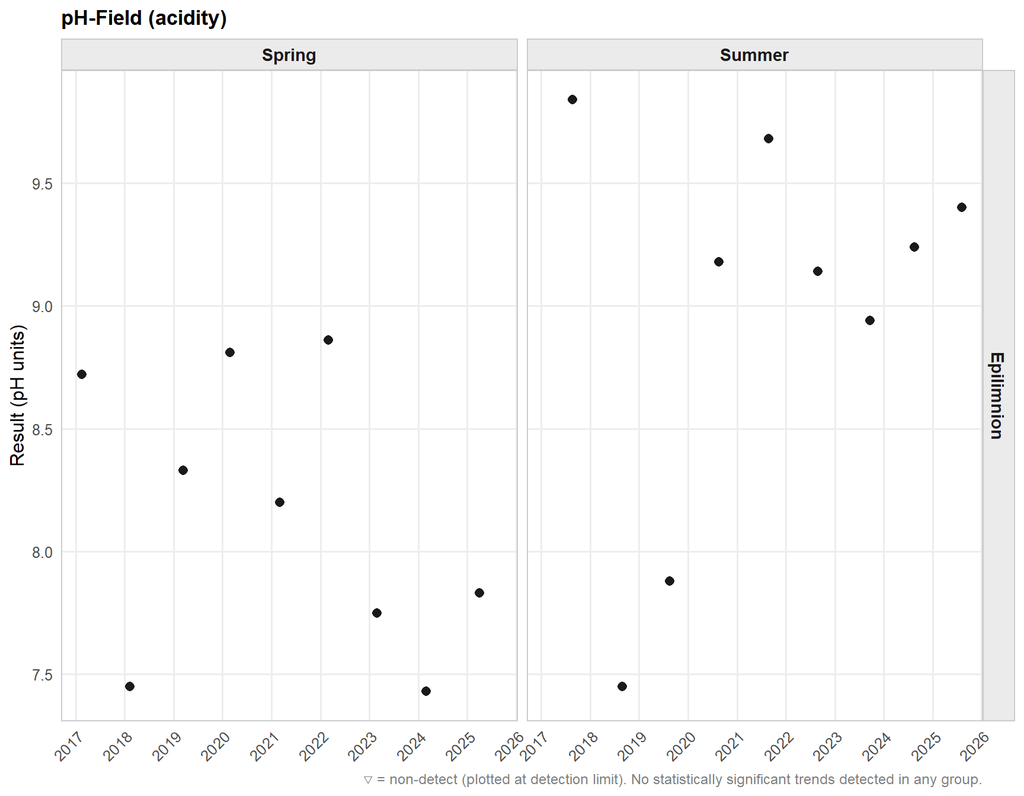

**▶ Summary Statistics Table**

**Quamichan Lake**

pH-Field (acidity) (pH units)

| N | Min<sup>1</sup> | 10th %ile | Median | Mean | 90th %ile | Max |
| --- | --- | --- | --- | --- | --- | --- |
| Epilimnion — Summer |  |  |  |  |  |  |
| 9 | 7.45 | 7.79 | 9.18 | 8.97 | 9.71 | 9.84 |
| Epilimnion — Spring |  |  |  |  |  |  |
| 9 | 7.43 | 7.45 | 8.2 | 8.15 | 8.82 | 8.86 |

<sup>1</sup> < indicates non-detect; value shown is the detection limit.

##### Specific Conductivity-Field (elec. cond.)

—

No simple [BC Aquatic Life Guideline](https://www2.gov.bc.ca/gov/content?id=044DD64C7E24415D83D07430964113C9) available for this parameter

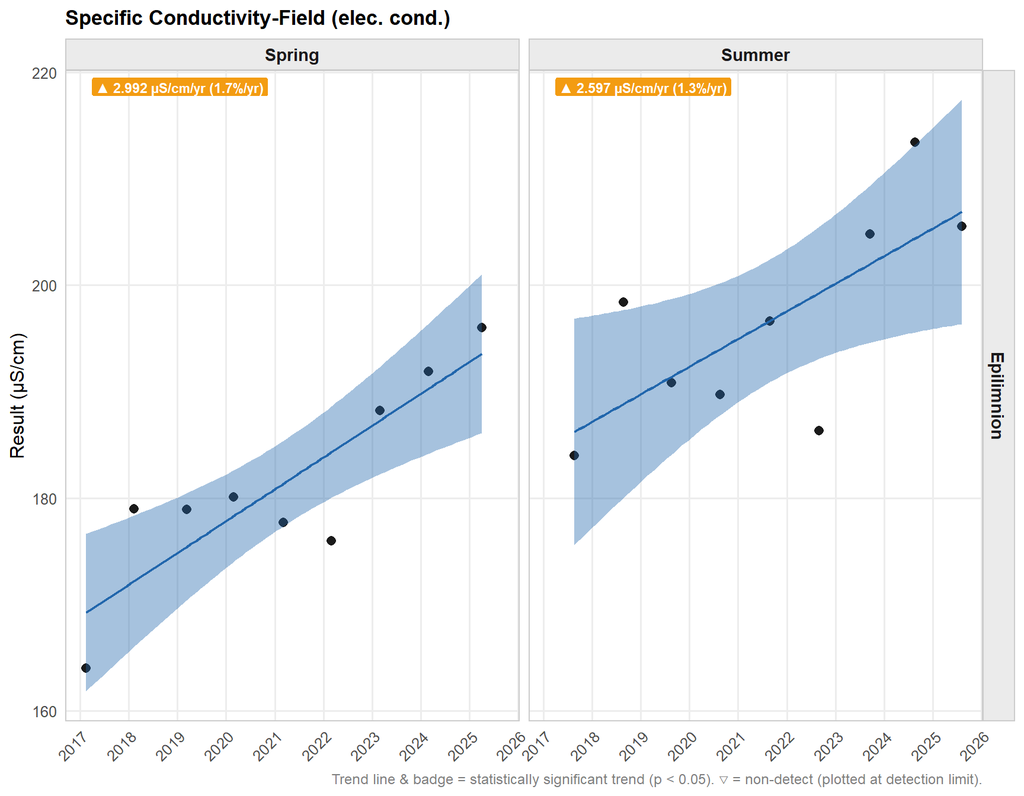

**▶ Summary Statistics Table**

**Quamichan Lake**

Specific Conductivity-Field (elec. cond.) (µS/cm)

| N | Min<sup>1</sup> | 10th %ile | Median | Mean | 90th %ile | Max |
| --- | --- | --- | --- | --- | --- | --- |
| Epilimnion — Summer |  |  |  |  |  |  |
| 9 | 184 | 186 | 197 | 197 | 207 | 213 |
| Epilimnion — Spring |  |  |  |  |  |  |
| 9 | 164 | 174 | 179 | 181 | 193 | 196 |

<sup>1</sup> < indicates non-detect; value shown is the detection limit.

##### Temperature-Field (temp.)

—

No simple [BC Aquatic Life Guideline](https://www2.gov.bc.ca/gov/content?id=044DD64C7E24415D83D07430964113C9) available for this parameter

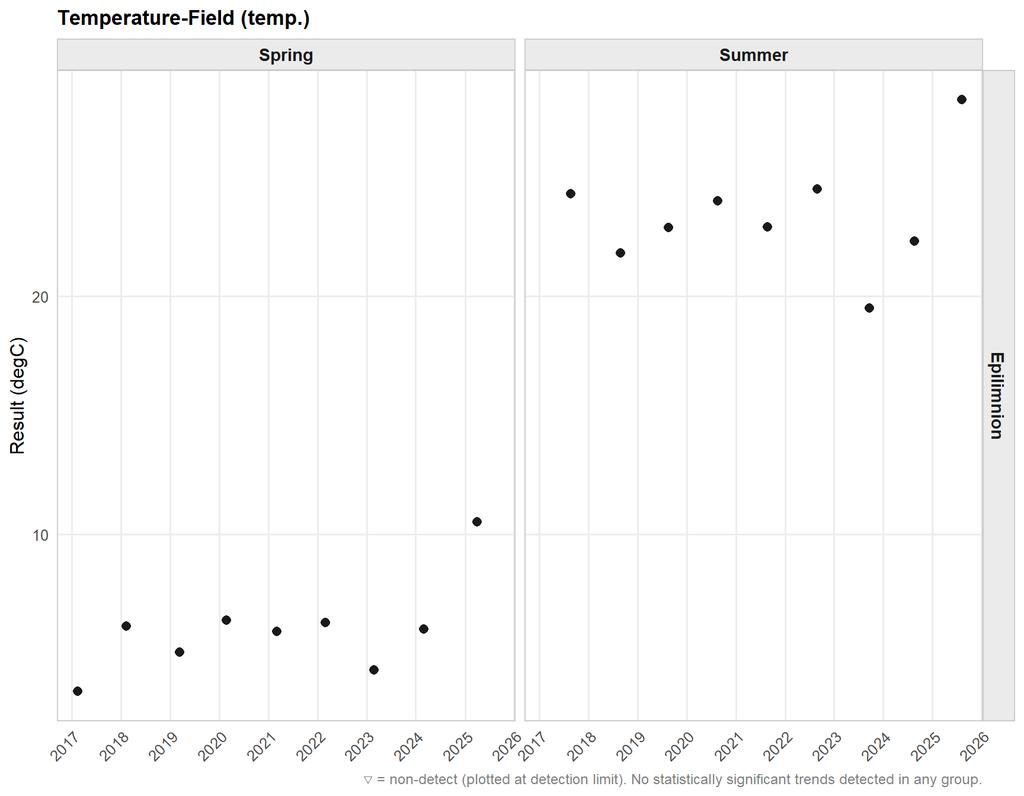

**▶ Summary Statistics Table**

**Quamichan Lake**

Temperature-Field (temp.) (degC)

| N | Min<sup>1</sup> | 10th %ile | Median | Mean | 90th %ile | Max |
| --- | --- | --- | --- | --- | --- | --- |
| Epilimnion — Summer |  |  |  |  |  |  |
| 9 | 19.5 | 21.3 | 22.9 | 23.4 | 25.2 | 28.2 |
| Epilimnion — Spring |  |  |  |  |  |  |
| 9 | 3.39 | 4.1 | 6 | 5.99 | 7.2 | 10.5 |

<sup>1</sup> < indicates non-detect; value shown is the detection limit.

#### **General**

##### Carbon Dissolved Organic (fl. conc.)

—

No simple [BC Aquatic Life Guideline](https://www2.gov.bc.ca/gov/content?id=044DD64C7E24415D83D07430964113C9) available for this parameter

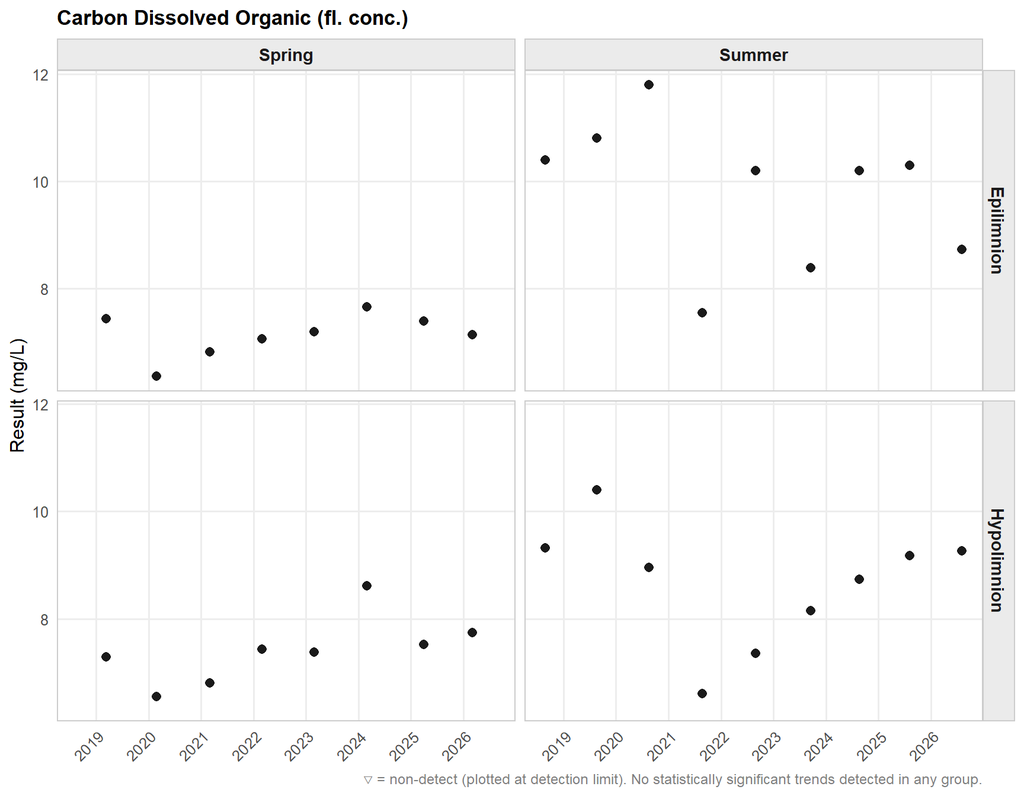

**▶ Summary Statistics Table**

**Quamichan Lake**

Carbon Dissolved Organic (fl. conc.) (mg/L)

| N | Min<sup>1</sup> | 10th %ile | Median | Mean | 90th %ile | Max |
| --- | --- | --- | --- | --- | --- | --- |
| Hypolimnion — Summer |  |  |  |  |  |  |
| 9 | 6.61 | 7.21 | 8.96 | 8.67 | 9.54 | 10.4 |
| Hypolimnion — Spring |  |  |  |  |  |  |
| 8 | 6.55 | 6.73 | 7.41 | 7.42 | 8 | 8.61 |
| Epilimnion — Summer |  |  |  |  |  |  |
| 9 | 7.55 | 8.22 | 10.2 | 9.82 | 11 | 11.8 |
| Epilimnion — Spring |  |  |  |  |  |  |
| 8 | 6.37 | 6.68 | 7.17 | 7.14 | 7.51 | 7.66 |

<sup>1</sup> < indicates non-detect; value shown is the detection limit.

##### Carbon Total Organic (fl. conc.)

—

No simple [BC Aquatic Life Guideline](https://www2.gov.bc.ca/gov/content?id=044DD64C7E24415D83D07430964113C9) available for this parameter

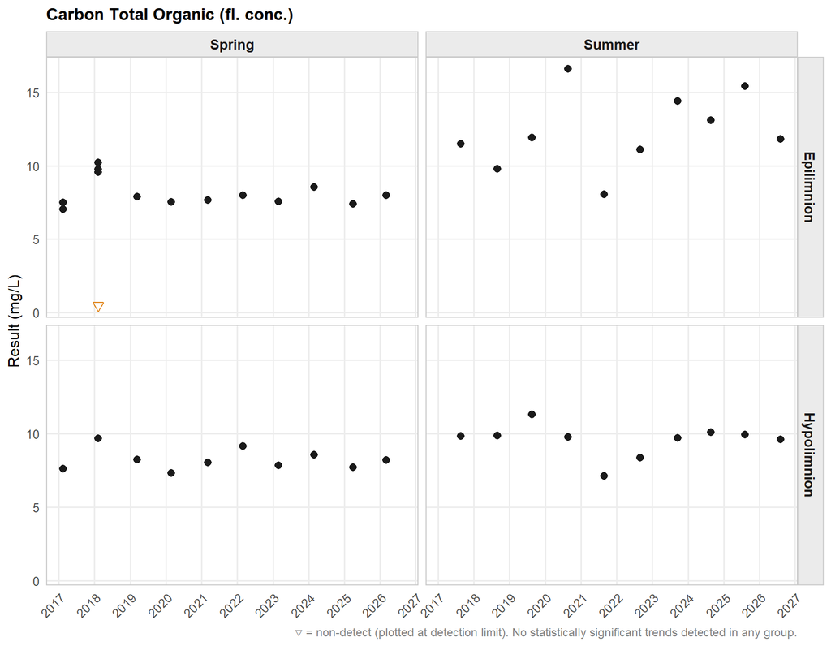

**▶ Summary Statistics Table**

**Quamichan Lake**

Carbon Total Organic (fl. conc.) (mg/L)

| N | Min<sup>1</sup> | 10th %ile | Median | Mean | 90th %ile | Max |
| --- | --- | --- | --- | --- | --- | --- |
| Hypolimnion — Summer |  |  |  |  |  |  |
| 10 | 7.13 | 8.25 | 9.82 | 9.57 | 10.2 | 11.3 |
| Hypolimnion — Spring |  |  |  |  |  |  |
| 10 | 7.32 | 7.58 | 8.12 | 8.24 | 9.21 | 9.69 |
| Epilimnion — Summer |  |  |  |  |  |  |
| 10 | 8.06 | 9.61 | 11.9 | 12.4 | 15.5 | 16.6 |
| Epilimnion — Spring |  |  |  |  |  |  |
| 14 | <0.5 | 7.14 | 7.78 | 7.65 | 9.69 | 10.2 |

<sup>1</sup> < indicates non-detect; value shown is the detection limit.

##### Chlorophyll A (fl. conc.)

—

No simple [BC Aquatic Life Guideline](https://www2.gov.bc.ca/gov/content?id=044DD64C7E24415D83D07430964113C9) available for this parameter

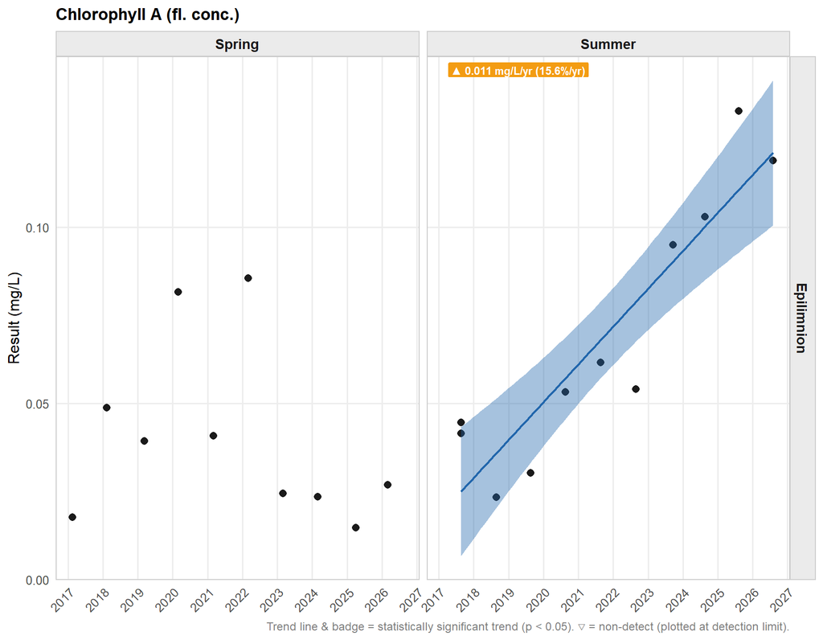

**▶ Summary Statistics Table**

**Quamichan Lake**

Chlorophyll A (fl. conc.) (mg/L)

| N | Min<sup>1</sup> | 10th %ile | Median | Mean | 90th %ile | Max |
| --- | --- | --- | --- | --- | --- | --- |
| Epilimnion — Summer |  |  |  |  |  |  |
| 11 | 0.0234 | 0.0303 | 0.054 | 0.069 | 0.119 | 0.133 |
| Epilimnion — Spring |  |  |  |  |  |  |
| 10 | 0.0147 | 0.0174 | 0.0331 | 0.0403 | 0.082 | 0.0855 |

<sup>1</sup> < indicates non-detect; value shown is the detection limit.

##### pH (acidity)

—

No simple [BC Aquatic Life Guideline](https://www2.gov.bc.ca/gov/content?id=044DD64C7E24415D83D07430964113C9) available for this parameter

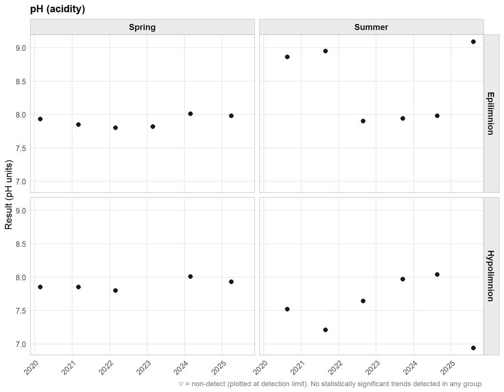

**▶ Summary Statistics Table**

**Quamichan Lake**

pH (acidity) (pH units)

| N | Min<sup>1</sup> | 10th %ile | Median | Mean | 90th %ile | Max |
| --- | --- | --- | --- | --- | --- | --- |
| Hypolimnion — Summer |  |  |  |  |  |  |
| 6 | 6.94 | 7.08 | 7.58 | 7.55 | 8 | 8.04 |
| Hypolimnion — Spring |  |  |  |  |  |  |
| 5 | 7.8 | 7.82 | 7.85 | 7.89 | 7.98 | 8.01 |
| Epilimnion — Summer |  |  |  |  |  |  |
| 6 | 7.9 | 7.92 | 8.42 | 8.45 | 9.02 | 9.09 |
| Epilimnion — Spring |  |  |  |  |  |  |
| 6 | 7.8 | 7.81 | 7.89 | 7.9 | 8 | 8.01 |

<sup>1</sup> < indicates non-detect; value shown is the detection limit.

##### Specific Conductance (elec. cond.)

—

No simple [BC Aquatic Life Guideline](https://www2.gov.bc.ca/gov/content?id=044DD64C7E24415D83D07430964113C9) available for this parameter

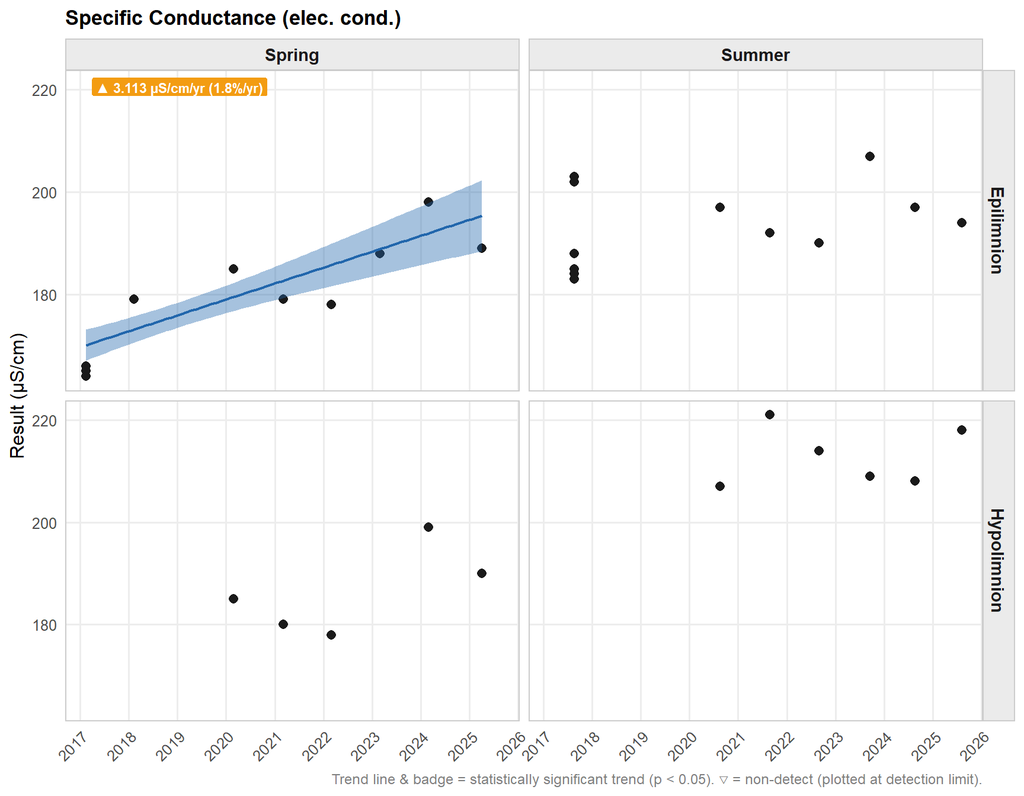

**▶ Summary Statistics Table**

**Quamichan Lake**

Specific Conductance (elec. cond.) (µS/cm)

| N | Min<sup>1</sup> | 10th %ile | Median | Mean | 90th %ile | Max |
| --- | --- | --- | --- | --- | --- | --- |
| Hypolimnion — Summer |  |  |  |  |  |  |
| 6 | 207 | 208 | 212 | 213 | 220 | 221 |
| Hypolimnion — Spring |  |  |  |  |  |  |
| 5 | 178 | 179 | 185 | 186 | 195 | 199 |
| Epilimnion — Summer |  |  |  |  |  |  |
| 14 | 183 | 183 | 191 | 192 | 203 | 207 |
| Epilimnion — Spring |  |  |  |  |  |  |
| 24 | 164 | 165 | 179 | 176 | 187 | 198 |

<sup>1</sup> < indicates non-detect; value shown is the detection limit.

##### Turbidity (turb.)

—

No simple [BC Aquatic Life Guideline](https://www2.gov.bc.ca/gov/content?id=044DD64C7E24415D83D07430964113C9) available for this parameter

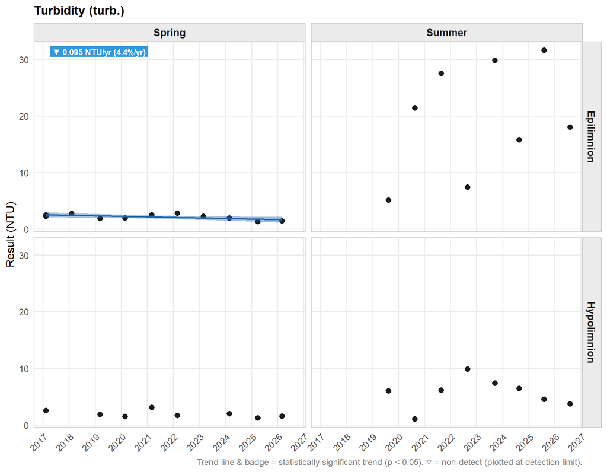

**▶ Summary Statistics Table**

**Quamichan Lake**

Turbidity (turb.) (NTU)

| N | Min<sup>1</sup> | 10th %ile | Median | Mean | 90th %ile | Max |
| --- | --- | --- | --- | --- | --- | --- |
| Hypolimnion — Summer |  |  |  |  |  |  |
| 8 | 1.08 | 2.92 | 6.1 | 5.65 | 8.11 | 9.88 |
| Hypolimnion — Spring |  |  |  |  |  |  |
| 8 | 1.22 | 1.39 | 1.75 | 1.92 | 2.72 | 3.11 |
| Epilimnion — Summer |  |  |  |  |  |  |
| 8 | 5.1 | 6.7 | 19.7 | 19.6 | 30.3 | 31.6 |
| Epilimnion — Spring |  |  |  |  |  |  |
| 11 | 1.32 | 1.45 | 2.23 | 2.14 | 2.73 | 2.8 |

<sup>1</sup> < indicates non-detect; value shown is the detection limit.

#### **Major Ions**

##### Chloride Dissolved (fl. conc.)

✓

[BC Aquatic Life Guideline](https://www2.gov.bc.ca/gov/content/environment/air-land-water/water/water-quality/water-quality-guidelines/approved-water-quality-guidelines) · Long-term chronic (Upper Limit) Aquatic Life - Freshwater

≤150 mg/L

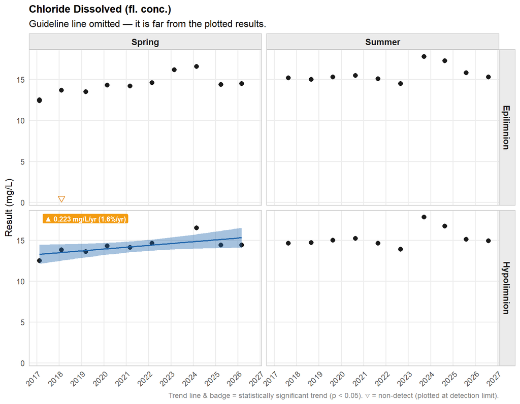

**▶ Summary Statistics Table**

**Quamichan Lake**

Chloride Dissolved (fl. conc.) (mg/L)

| N | Min<sup>1</sup> | 10th %ile | Median | Mean | 90th %ile | Max |
| --- | --- | --- | --- | --- | --- | --- |
| Hypolimnion — Summer |  |  |  |  |  |  |
| 10 | 13.9 | 14.5 | 15 | 15.2 | 16.8 | 17.8 |
| Hypolimnion — Spring |  |  |  |  |  |  |
| 9 | 12.5 | 13.4 | 14.3 | 14.2 | 15 | 16.5 |
| Epilimnion — Summer |  |  |  |  |  |  |
| 10 | 14.5 | 15 | 15.3 | 15.7 | 17.4 | 17.8 |
| Epilimnion — Spring |  |  |  |  |  |  |
| 14 | <0.5 | 12.4 | 14 | 13.2 | 15.7 | 16.6 |

<sup>1</sup> < indicates non-detect; value shown is the detection limit.

##### Hardness Total (Total) (fl. conc.)

—

No simple [BC Aquatic Life Guideline](https://www2.gov.bc.ca/gov/content?id=044DD64C7E24415D83D07430964113C9) available for this parameter

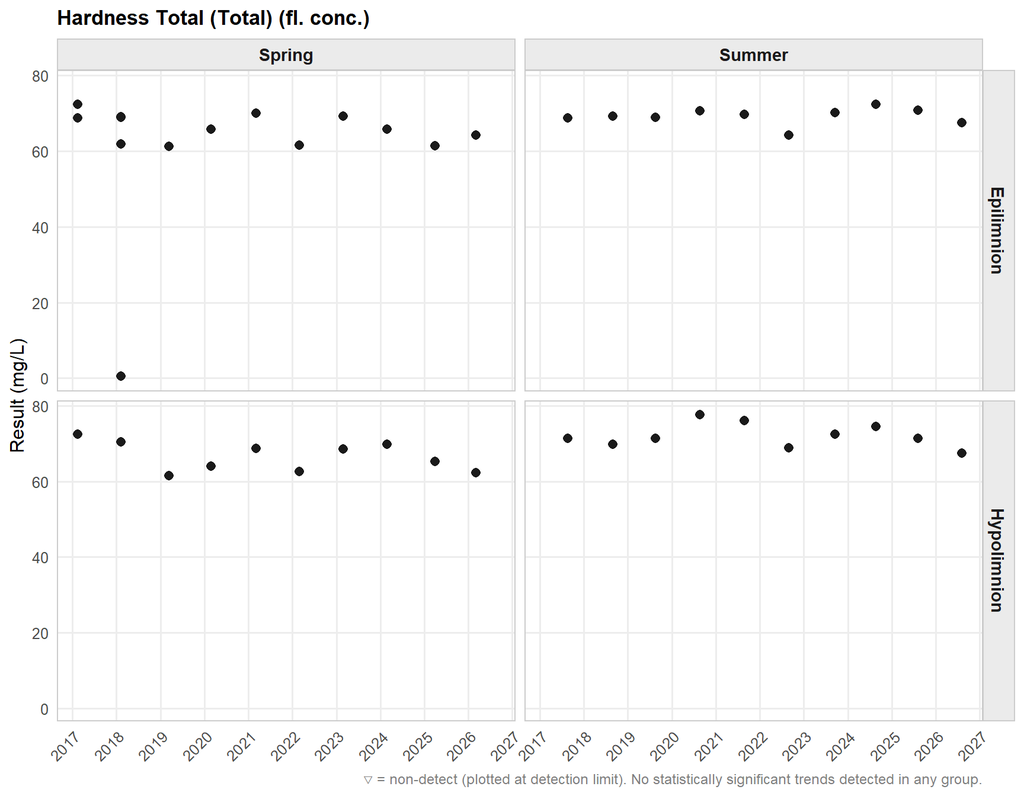

**▶ Summary Statistics Table**

**Quamichan Lake**

Hardness Total (Total) (fl. conc.) (mg/L)

| N | Min<sup>1</sup> | 10th %ile | Median | Mean | 90th %ile | Max |
| --- | --- | --- | --- | --- | --- | --- |
| Hypolimnion — Summer |  |  |  |  |  |  |
| 10 | 67.4 | 68.8 | 71.4 | 72.1 | 76.2 | 77.6 |
| Hypolimnion — Spring |  |  |  |  |  |  |
| 10 | 61.4 | 62.2 | 66.9 | 66.6 | 70.6 | 72.4 |
| Epilimnion — Summer |  |  |  |  |  |  |
| 10 | 64.3 | 67.3 | 69.5 | 69.3 | 71 | 72.4 |
| Epilimnion — Spring |  |  |  |  |  |  |
| 14 | 0.537 | 61.4 | 65.8 | 61.5 | 69.8 | 72.4 |

<sup>1</sup> < indicates non-detect; value shown is the detection limit.

##### Sulfate Dissolved (fl. conc.)

—

No simple [BC Aquatic Life Guideline](https://www2.gov.bc.ca/gov/content?id=044DD64C7E24415D83D07430964113C9) available for this parameter

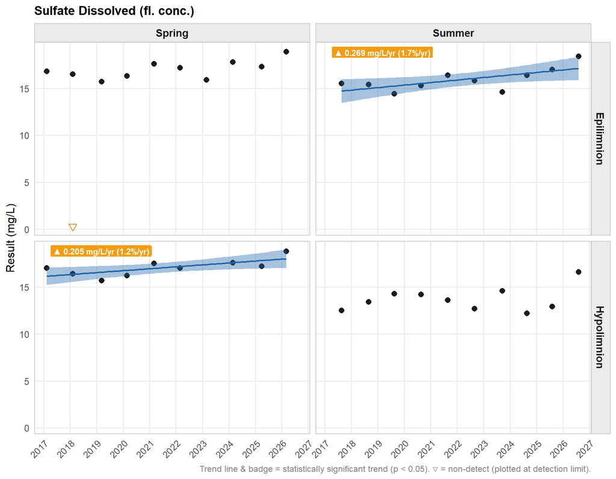

**▶ Summary Statistics Table**

**Quamichan Lake**

Sulfate Dissolved (fl. conc.) (mg/L)

| N | Min<sup>1</sup> | 10th %ile | Median | Mean | 90th %ile | Max |
| --- | --- | --- | --- | --- | --- | --- |
| Hypolimnion — Summer |  |  |  |  |  |  |
| 10 | 12.2 | 12.5 | 13.5 | 13.7 | 14.8 | 16.6 |
| Hypolimnion — Spring |  |  |  |  |  |  |
| 9 | 15.7 | 16.1 | 17 | 17 | 17.8 | 18.8 |
| Epilimnion — Summer |  |  |  |  |  |  |
| 10 | 14.4 | 14.6 | 15.6 | 15.9 | 17.1 | 18.4 |
| Epilimnion — Spring |  |  |  |  |  |  |
| 14 | <0.3 | 15.8 | 16.6 | 15.7 | 17.7 | 18.9 |

<sup>1</sup> < indicates non-detect; value shown is the detection limit.

#### **Nutrients**

##### Nitrate (NO3) Dissolved (fl. conc.)

✓

[BC Aquatic Life Guideline](https://www2.gov.bc.ca/gov/content/environment/air-land-water/water/water-quality/water-quality-guidelines/approved-water-quality-guidelines) · Long-term chronic (Upper Limit) Aquatic Life - Freshwater

≤3 mg/L

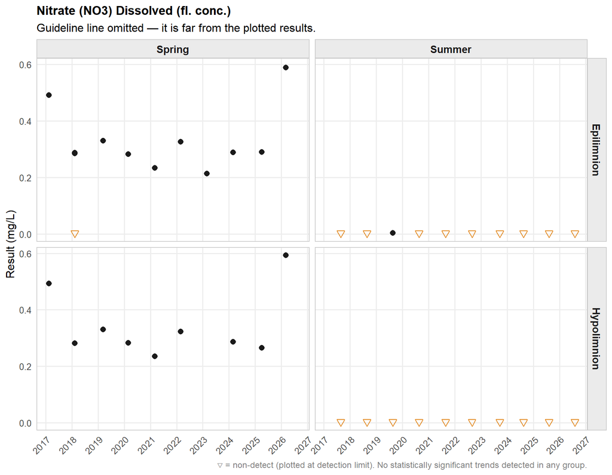

**▶ Summary Statistics Table**

**Quamichan Lake**

Nitrate (NO3) Dissolved (fl. conc.) (mg/L)

| N | Min<sup>1</sup> | 10th %ile | Median | Mean | 90th %ile | Max |
| --- | --- | --- | --- | --- | --- | --- |
| Hypolimnion — Summer |  |  |  |  |  |  |
| 10 | <0.003 | <0.003 | <0.003 | <0.003 | <0.003 | <0.003 |
| Hypolimnion — Spring |  |  |  |  |  |  |
| 9 | 0.235 | 0.259 | 0.287 | 0.343 | 0.513 | 0.593 |
| Epilimnion — Summer |  |  |  |  |  |  |
| 10 | <0.003 | <0.003 | <0.003 | 0.00301 | 0.00301 | 0.0031 |
| Epilimnion — Spring |  |  |  |  |  |  |
| 14 | <0.003 | 0.22 | 0.288 | 0.314 | 0.492 | 0.589 |

<sup>1</sup> < indicates non-detect; value shown is the detection limit.

##### Nitrate(NO3) + Nitrite(NO2) Dissolved (fl. conc.)

—

No simple [BC Aquatic Life Guideline](https://www2.gov.bc.ca/gov/content?id=044DD64C7E24415D83D07430964113C9) available for this parameter

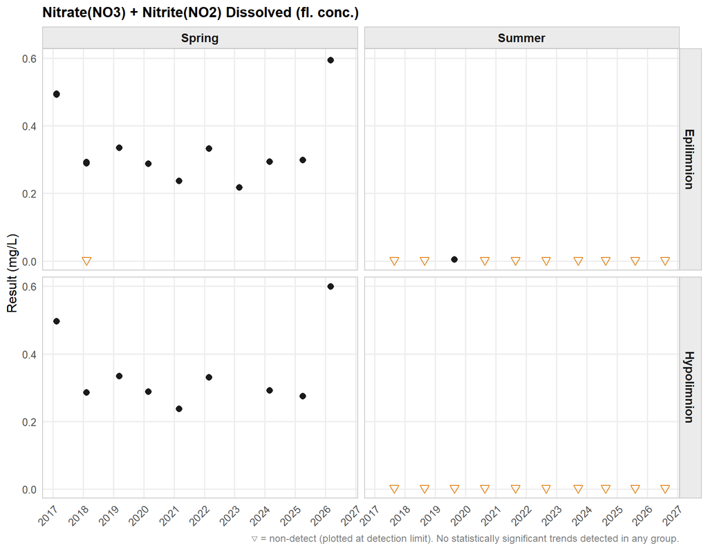

**▶ Summary Statistics Table**

**Quamichan Lake**

Nitrate(NO3) + Nitrite(NO2) Dissolved (fl. conc.) (mg/L)

| N | Min<sup>1</sup> | 10th %ile | Median | Mean | 90th %ile | Max |
| --- | --- | --- | --- | --- | --- | --- |
| Hypolimnion — Summer |  |  |  |  |  |  |
| 10 | <0.0032 | <0.0032 | <0.0032 | <0.0032 | <0.0032 | <0.0032 |
| Hypolimnion — Spring |  |  |  |  |  |  |
| 9 | 0.238 | 0.268 | 0.292 | 0.349 | 0.517 | 0.599 |
| Epilimnion — Summer |  |  |  |  |  |  |
| 10 | <0.0032 | <0.0032 | <0.0032 | 0.00332 | 0.00332 | 0.0044 |
| Epilimnion — Spring |  |  |  |  |  |  |
| 14 | <0.0032 | 0.223 | 0.293 | 0.319 | 0.494 | 0.594 |

<sup>1</sup> < indicates non-detect; value shown is the detection limit.

##### Nitrogen - Nitrite Dissolved (NO2) (fl. conc.)

—

No simple [BC Aquatic Life Guideline](https://www2.gov.bc.ca/gov/content?id=044DD64C7E24415D83D07430964113C9) available for this parameter

0.02 - 0.2 mg/L but varies by site conditions

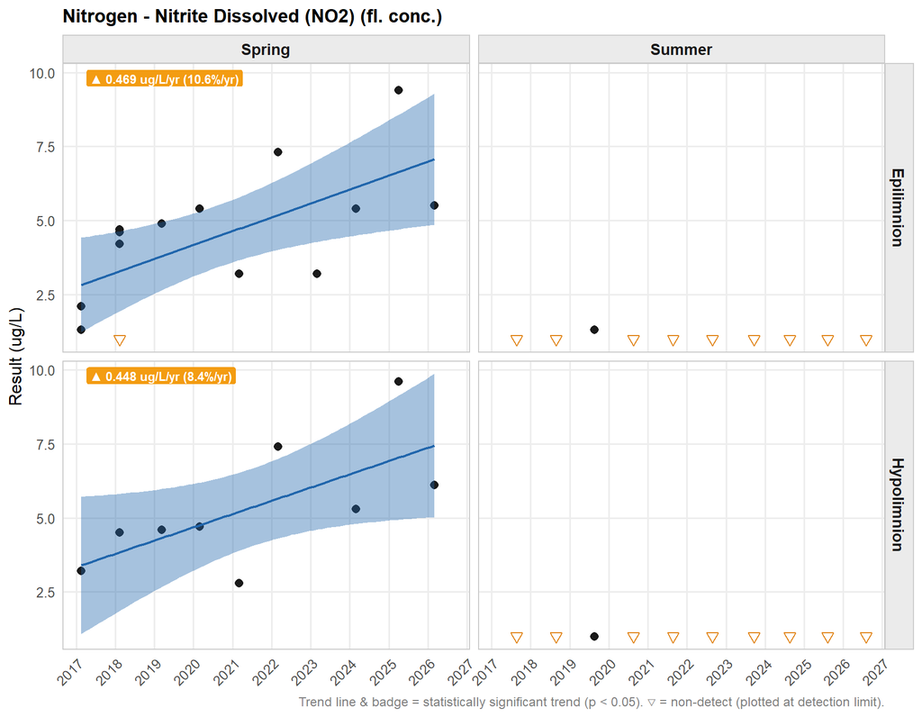

**▶ Summary Statistics Table**

**Quamichan Lake**

Nitrogen - Nitrite Dissolved (NO2) (fl. conc.) (ug/L)

| N | Min<sup>1</sup> | 10th %ile | Median | Mean | 90th %ile | Max |
| --- | --- | --- | --- | --- | --- | --- |
| Hypolimnion — Summer |  |  |  |  |  |  |
| 10 | <1 | <1 | <1 | <1 | <1 | <1 |
| Hypolimnion — Spring |  |  |  |  |  |  |
| 9 | 2.8 | 3.12 | 4.7 | 5.36 | 7.84 | 9.6 |
| Epilimnion — Summer |  |  |  |  |  |  |
| 10 | <1 | <1 | <1 | 1.03 | 1.03 | 1.3 |
| Epilimnion — Spring |  |  |  |  |  |  |
| 14 | <1 | 1.54 | 4.65 | 4.44 | 6.76 | 9.4 |

<sup>1</sup> < indicates non-detect; value shown is the detection limit.

##### Nitrogen Ammonia Total (fl. conc.)

—

No simple [BC Aquatic Life Guideline](https://www2.gov.bc.ca/gov/content?id=044DD64C7E24415D83D07430964113C9) available for this parameter

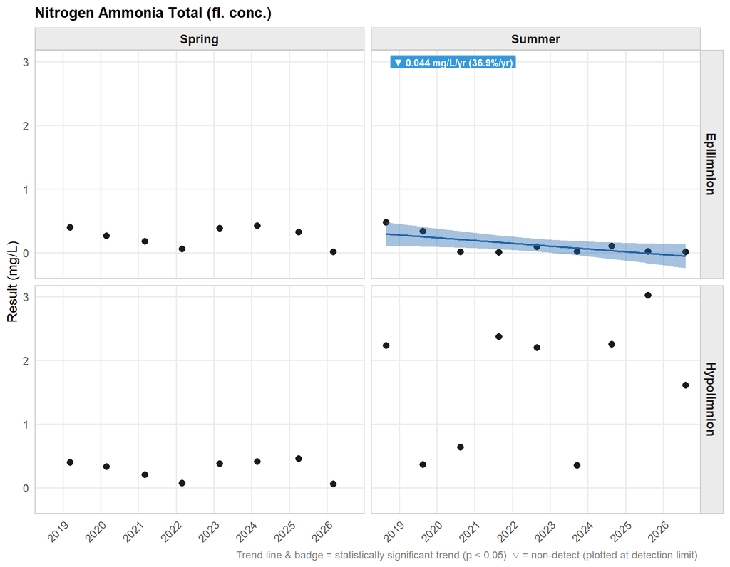

**▶ Summary Statistics Table**

**Quamichan Lake**

Nitrogen Ammonia Total (fl. conc.) (mg/L)

| N | Min<sup>1</sup> | 10th %ile | Median | Mean | 90th %ile | Max |
| --- | --- | --- | --- | --- | --- | --- |
| Hypolimnion — Summer |  |  |  |  |  |  |
| 9 | 0.351 | 0.365 | 2.2 | 1.67 | 2.5 | 3.02 |
| Hypolimnion — Spring |  |  |  |  |  |  |
| 8 | 0.0588 | 0.0677 | 0.354 | 0.289 | 0.426 | 0.456 |
| Epilimnion — Summer |  |  |  |  |  |  |
| 9 | 0.008 | 0.0107 | 0.0166 | 0.119 | 0.365 | 0.472 |
| Epilimnion — Spring |  |  |  |  |  |  |
| 8 | 0.0134 | 0.0426 | 0.292 | 0.254 | 0.404 | 0.422 |

<sup>1</sup> < indicates non-detect; value shown is the detection limit.

##### Nitrogen Kjel.Tot(N) (fl. conc.)

—

No simple [BC Aquatic Life Guideline](https://www2.gov.bc.ca/gov/content?id=044DD64C7E24415D83D07430964113C9) available for this parameter

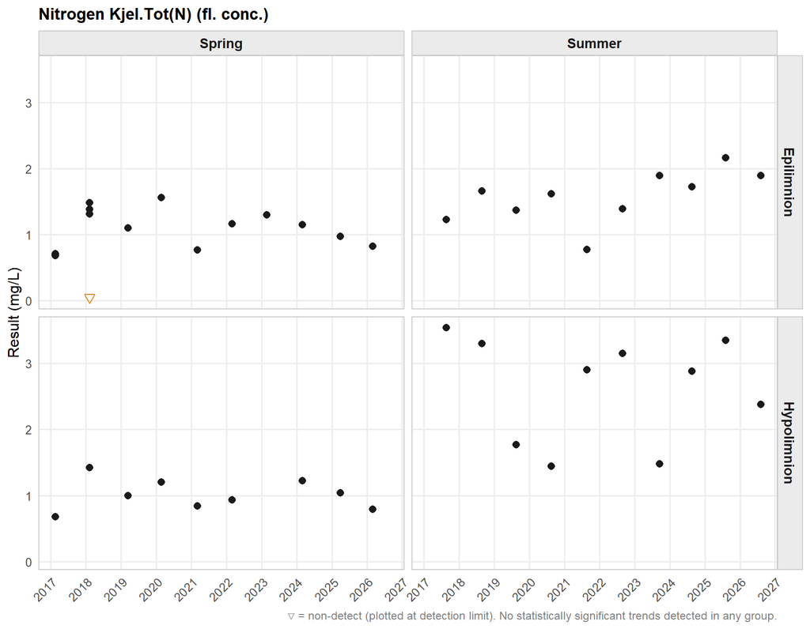

**▶ Summary Statistics Table**

**Quamichan Lake**

Nitrogen Kjel.Tot(N) (fl. conc.) (mg/L)

| N | Min<sup>1</sup> | 10th %ile | Median | Mean | 90th %ile | Max |
| --- | --- | --- | --- | --- | --- | --- |
| Hypolimnion — Summer |  |  |  |  |  |  |
| 10 | 1.44 | 1.48 | 2.89 | 2.62 | 3.37 | 3.54 |
| Hypolimnion — Spring |  |  |  |  |  |  |
| 9 | 0.68 | 0.769 | 1 | 1.01 | 1.26 | 1.42 |
| Epilimnion — Summer |  |  |  |  |  |  |
| 10 | 0.775 | 1.18 | 1.64 | 1.57 | 1.92 | 2.16 |
| Epilimnion — Spring |  |  |  |  |  |  |
| 14 | <0.05 | 0.689 | 1.12 | 1.03 | 1.45 | 1.56 |

<sup>1</sup> < indicates non-detect; value shown is the detection limit.

##### Nitrogen Organic-Total (fl. conc.)

—

No simple [BC Aquatic Life Guideline](https://www2.gov.bc.ca/gov/content?id=044DD64C7E24415D83D07430964113C9) available for this parameter

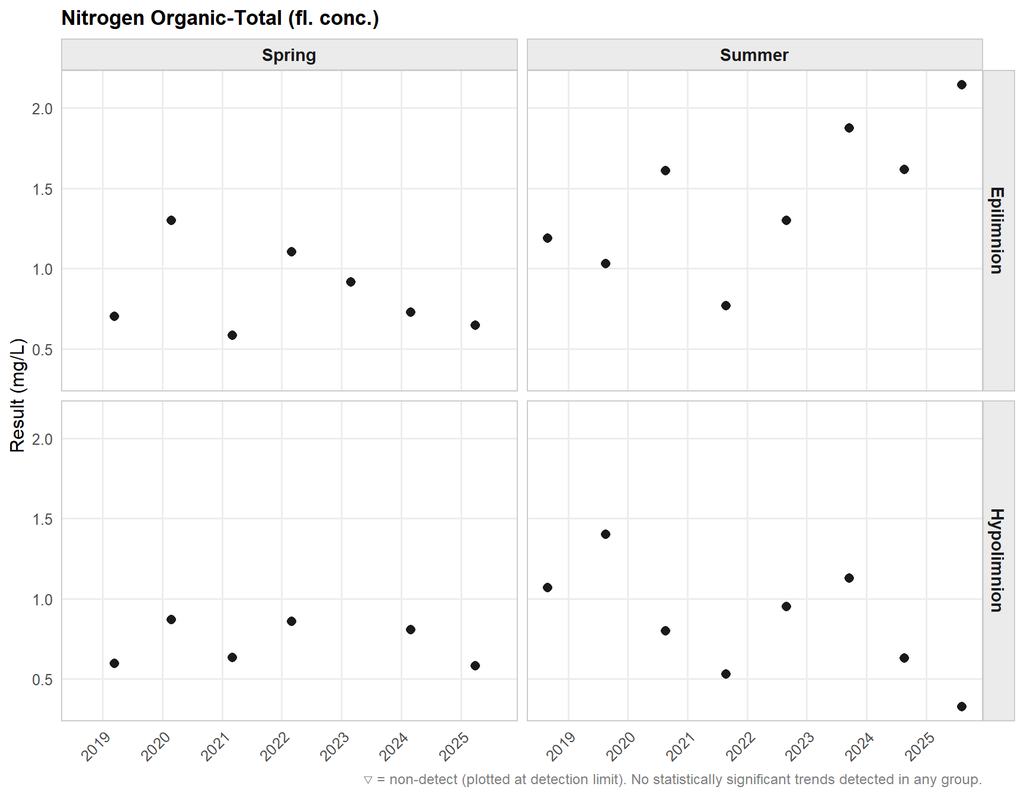

**▶ Summary Statistics Table**

**Quamichan Lake**

Nitrogen Organic-Total (fl. conc.) (mg/L)

| N | Min<sup>1</sup> | 10th %ile | Median | Mean | 90th %ile | Max |
| --- | --- | --- | --- | --- | --- | --- |
| Hypolimnion — Summer |  |  |  |  |  |  |
| 8 | 0.33 | 0.47 | 0.876 | 0.855 | 1.21 | 1.4 |
| Hypolimnion — Spring |  |  |  |  |  |  |
| 6 | 0.584 | 0.591 | 0.721 | 0.725 | 0.864 | 0.869 |
| Epilimnion — Summer |  |  |  |  |  |  |
| 8 | 0.767 | 0.952 | 1.45 | 1.44 | 1.95 | 2.15 |
| Epilimnion — Spring |  |  |  |  |  |  |
| 7 | 0.583 | 0.623 | 0.728 | 0.855 | 1.18 | 1.3 |

<sup>1</sup> < indicates non-detect; value shown is the detection limit.

##### Nitrogen Total (fl. conc.)

—

No simple [BC Aquatic Life Guideline](https://www2.gov.bc.ca/gov/content?id=044DD64C7E24415D83D07430964113C9) available for this parameter

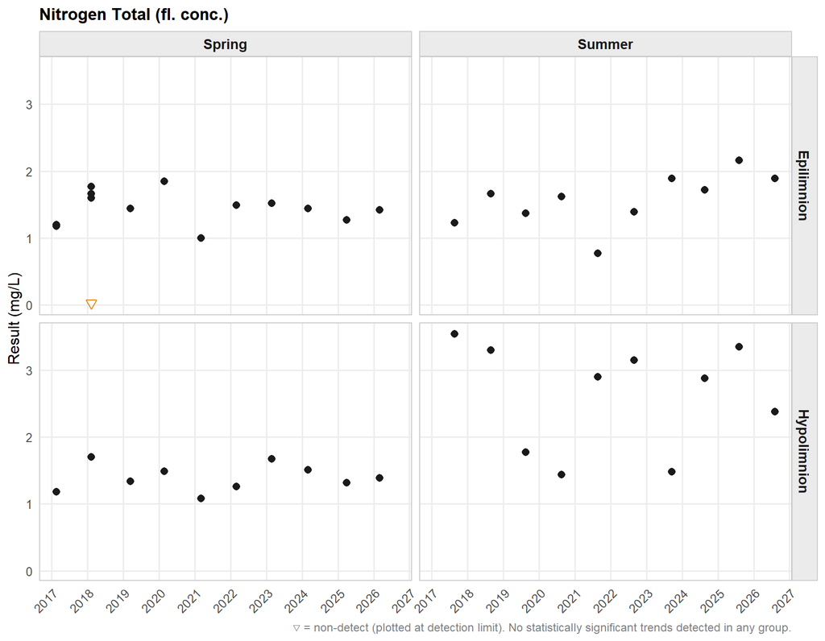

**▶ Summary Statistics Table**

**Quamichan Lake**

Nitrogen Total (fl. conc.) (mg/L)

| N | Min<sup>1</sup> | 10th %ile | Median | Mean | 90th %ile | Max |
| --- | --- | --- | --- | --- | --- | --- |
| Hypolimnion — Summer |  |  |  |  |  |  |
| 10 | 1.44 | 1.48 | 2.89 | 2.62 | 3.37 | 3.54 |
| Hypolimnion — Spring |  |  |  |  |  |  |
| 10 | 1.08 | 1.17 | 1.36 | 1.39 | 1.67 | 1.7 |
| Epilimnion — Summer |  |  |  |  |  |  |
| 10 | 0.775 | 1.18 | 1.64 | 1.57 | 1.92 | 2.16 |
| Epilimnion — Spring |  |  |  |  |  |  |
| 14 | <0.03 | 1.05 | 1.44 | 1.35 | 1.74 | 1.85 |

<sup>1</sup> < indicates non-detect; value shown is the detection limit.

##### Phosphorus Ort.Dis-P (fl. conc.)

—

No simple [BC Aquatic Life Guideline](https://www2.gov.bc.ca/gov/content?id=044DD64C7E24415D83D07430964113C9) available for this parameter

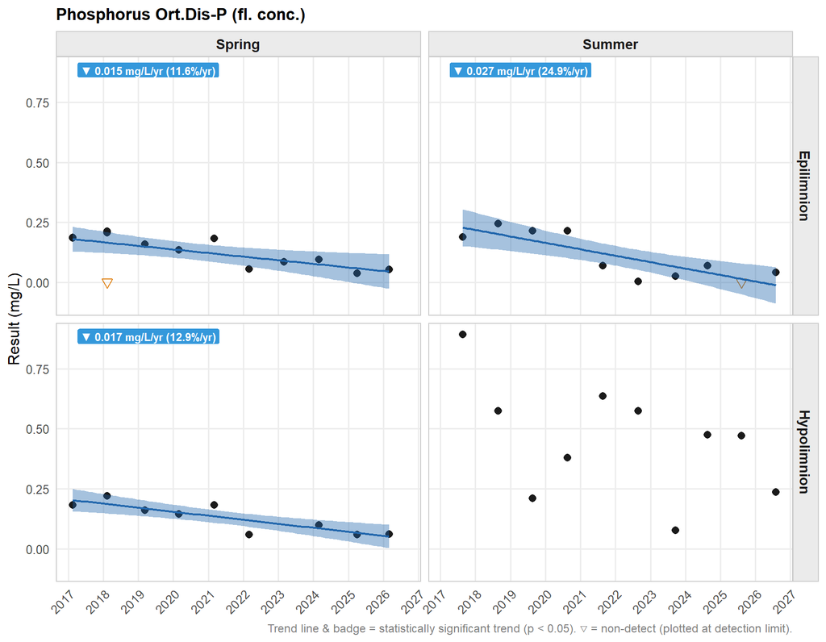

**▶ Summary Statistics Table**

**Quamichan Lake**

Phosphorus Ort.Dis-P (fl. conc.) (mg/L)

| N | Min<sup>1</sup> | 10th %ile | Median | Mean | 90th %ile | Max |
| --- | --- | --- | --- | --- | --- | --- |
| Hypolimnion — Summer |  |  |  |  |  |  |
| 10 | 0.0765 | 0.197 | 0.472 | 0.452 | 0.662 | 0.892 |
| Hypolimnion — Spring |  |  |  |  |  |  |
| 9 | 0.0578 | 0.0588 | 0.144 | 0.129 | 0.19 | 0.219 |
| Epilimnion — Summer |  |  |  |  |  |  |
| 10 | <0.001 | 0.00325 | 0.0705 | 0.108 | 0.218 | 0.245 |
| Epilimnion — Spring |  |  |  |  |  |  |
| 14 | <0.001 | 0.0421 | 0.147 | 0.129 | 0.208 | 0.213 |

<sup>1</sup> < indicates non-detect; value shown is the detection limit.

##### Phosphorus Total (fl. conc.)

⚠

[BC Aquatic Life Guideline](https://www2.gov.bc.ca/gov/content/environment/air-land-water/water/water-quality/water-quality-guidelines/approved-water-quality-guidelines) · Long-term chronic (Upper Limit) Aquatic Life - Freshwater

≤0.015 mg/L

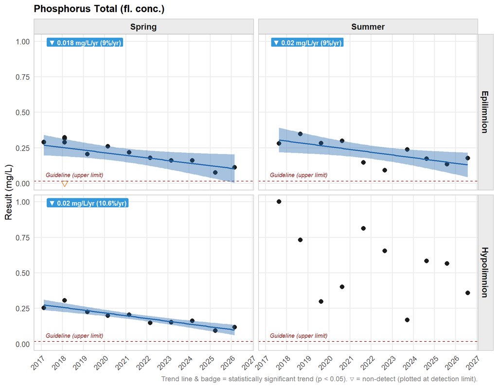

**▶ Summary Statistics Table**

**Quamichan Lake**

Phosphorus Total (fl. conc.) (mg/L)

| N | Min<sup>1</sup> | 10th %ile | Median | Mean | 90th %ile | Max<sup>2</sup> |
| --- | --- | --- | --- | --- | --- | --- |
| Hypolimnion — Summer |  |  |  |  |  |  |
| 10 | 0.168 | 0.283 | 0.573 | 0.556 | 0.83 | 1 |
| Hypolimnion — Spring |  |  |  |  |  |  |
| 10 | 0.0914 | 0.114 | 0.18 | 0.185 | 0.258 | 0.305 |
| Epilimnion — Summer |  |  |  |  |  |  |
| 10 | 0.0913 | 0.129 | 0.207 | 0.216 | 0.302 | 0.347 |
| Epilimnion — Spring |  |  |  |  |  |  |
| 14 | <0.002 | 0.0854 | 0.21 | 0.205 | 0.308 | 0.322 |

<sup>1</sup> < indicates non-detect; value shown is the detection limit.  
<sup>2</sup> Red = this group’s maximum result exceeds the BC Aquatic Life guideline.

##### Phosphorus Total Dissolved (fl. conc.)

—

No simple [BC Aquatic Life Guideline](https://www2.gov.bc.ca/gov/content?id=044DD64C7E24415D83D07430964113C9) available for this parameter

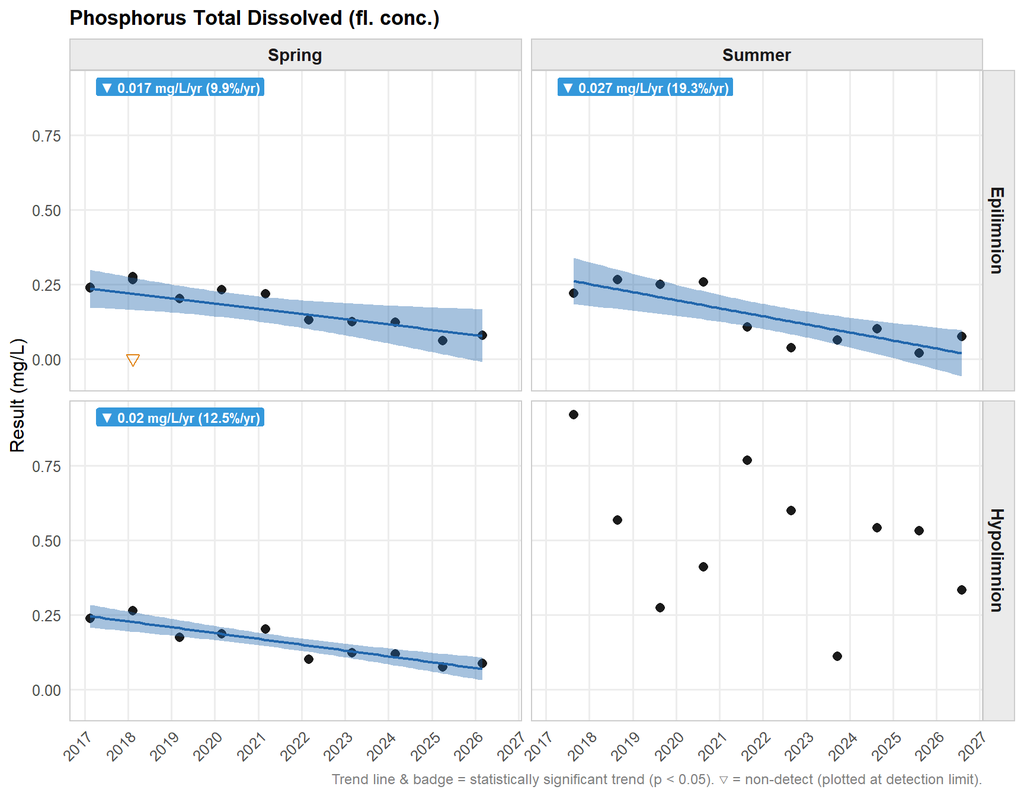

**▶ Summary Statistics Table**

**Quamichan Lake**

Phosphorus Total Dissolved (fl. conc.) (mg/L)

| N | Min<sup>1</sup> | 10th %ile | Median | Mean | 90th %ile | Max |
| --- | --- | --- | --- | --- | --- | --- |
| Hypolimnion — Summer |  |  |  |  |  |  |
| 10 | 0.11 | 0.257 | 0.536 | 0.505 | 0.783 | 0.92 |
| Hypolimnion — Spring |  |  |  |  |  |  |
| 10 | 0.0748 | 0.086 | 0.148 | 0.157 | 0.24 | 0.263 |
| Epilimnion — Summer |  |  |  |  |  |  |
| 10 | 0.0198 | 0.036 | 0.104 | 0.14 | 0.26 | 0.266 |
| Epilimnion — Spring |  |  |  |  |  |  |
| 14 | <0.002 | 0.0674 | 0.211 | 0.176 | 0.267 | 0.276 |

<sup>1</sup> < indicates non-detect; value shown is the detection limit.

##### Silica Reactive Diss (fl. conc.)

—

No simple [BC Aquatic Life Guideline](https://www2.gov.bc.ca/gov/content?id=044DD64C7E24415D83D07430964113C9) available for this parameter

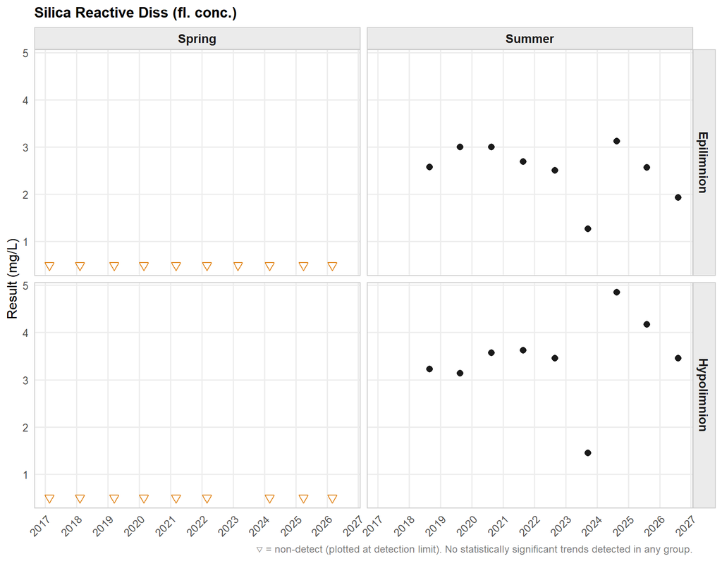

**▶ Summary Statistics Table**

**Quamichan Lake**

Silica Reactive Diss (fl. conc.) (mg/L)

| N | Min<sup>1</sup> | 10th %ile | Median | Mean | 90th %ile | Max |
| --- | --- | --- | --- | --- | --- | --- |
| Hypolimnion — Summer |  |  |  |  |  |  |
| 9 | 1.45 | 2.8 | 3.46 | 3.44 | 4.31 | 4.85 |
| Hypolimnion — Spring |  |  |  |  |  |  |
| 9 | <0.5 | <0.5 | <0.5 | <0.5 | <0.5 | <0.5 |
| Epilimnion — Summer |  |  |  |  |  |  |
| 9 | 1.27 | 1.8 | 2.58 | 2.52 | 3.02 | 3.12 |
| Epilimnion — Spring |  |  |  |  |  |  |
| 14 | <0.5 | <0.5 | <0.5 | <0.5 | <0.5 | <0.5 |

<sup>1</sup> < indicates non-detect; value shown is the detection limit.

#### **Metals - Total**

##### Aluminum Total (fl. conc.)

—

No simple [BC Aquatic Life Guideline](https://www2.gov.bc.ca/gov/content?id=044DD64C7E24415D83D07430964113C9) available for this parameter

Dependent on hardness, pH, and Dissolved Organic Carbon

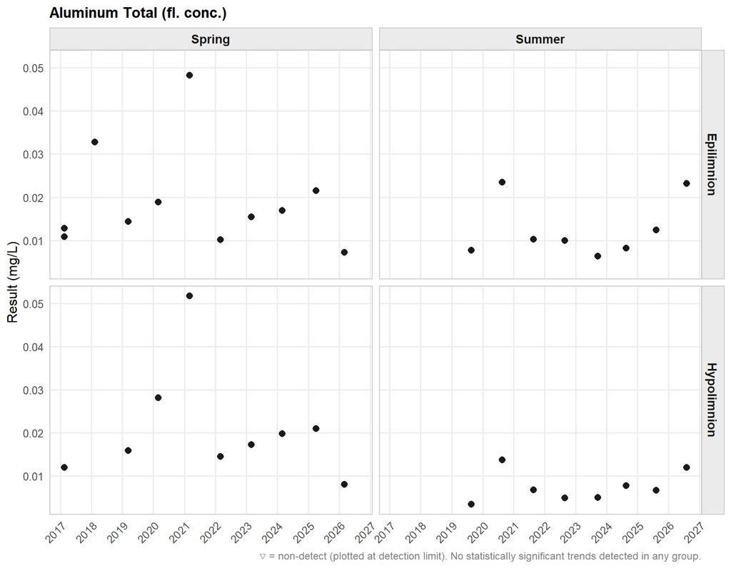

**▶ Summary Statistics Table**

**Quamichan Lake**

Aluminum Total (fl. conc.) (mg/L)

| N | Min<sup>1</sup> | 10th %ile | Median | Mean | 90th %ile | Max |
| --- | --- | --- | --- | --- | --- | --- |
| Hypolimnion — Summer |  |  |  |  |  |  |
| 8 | 0.00351 | 0.00454 | 0.00672 | 0.00755 | 0.0125 | 0.0137 |
| Hypolimnion — Spring |  |  |  |  |  |  |
| 9 | 0.00808 | 0.0112 | 0.0173 | 0.0209 | 0.0328 | 0.0517 |
| Epilimnion — Summer |  |  |  |  |  |  |
| 8 | 0.00633 | 0.00729 | 0.0101 | 0.0127 | 0.0233 | 0.0235 |
| Epilimnion — Spring |  |  |  |  |  |  |
| 11 | 0.00728 | 0.0102 | 0.0155 | 0.019 | 0.0328 | 0.0482 |

<sup>1</sup> < indicates non-detect; value shown is the detection limit.

##### Antimony Total (fl. conc.)

✓

[BC Aquatic Life Guideline](https://www2.gov.bc.ca/gov/content/environment/air-land-water/water/water-quality/water-quality-guidelines/approved-water-quality-guidelines) · Long-term chronic (Upper Limit) Aquatic Life - Freshwater

≤74 ug/L

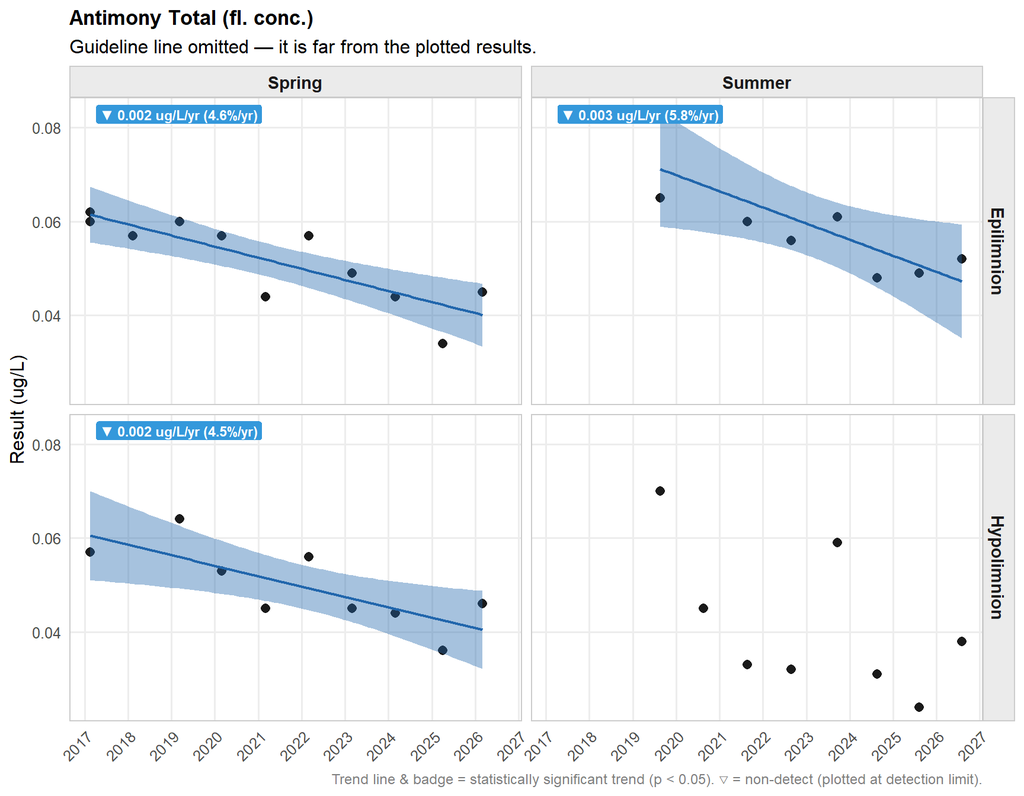

**▶ Summary Statistics Table**

**Quamichan Lake**

Antimony Total (fl. conc.) (ug/L)

| N | Min<sup>1</sup> | 10th %ile | Median | Mean | 90th %ile | Max |
| --- | --- | --- | --- | --- | --- | --- |
| Hypolimnion — Summer |  |  |  |  |  |  |
| 8 | 0.024 | 0.0289 | 0.0355 | 0.0415 | 0.0623 | 0.07 |
| Hypolimnion — Spring |  |  |  |  |  |  |
| 9 | 0.036 | 0.0424 | 0.046 | 0.0496 | 0.0584 | 0.064 |
| Epilimnion — Summer |  |  |  |  |  |  |
| 8 | 0.048 | 0.0487 | 0.058 | 0.0591 | 0.0701 | 0.082 |
| Epilimnion — Spring |  |  |  |  |  |  |
| 11 | 0.034 | 0.044 | 0.057 | 0.0517 | 0.06 | 0.062 |

<sup>1</sup> < indicates non-detect; value shown is the detection limit.

##### Arsenic Total (fl. conc.)

✓

[BC Aquatic Life Guideline](https://www2.gov.bc.ca/gov/content/environment/air-land-water/water/water-quality/water-quality-guidelines/approved-water-quality-guidelines) · Long-term chronic (Upper Limit) Aquatic Life - Freshwater

≤5 ug/L

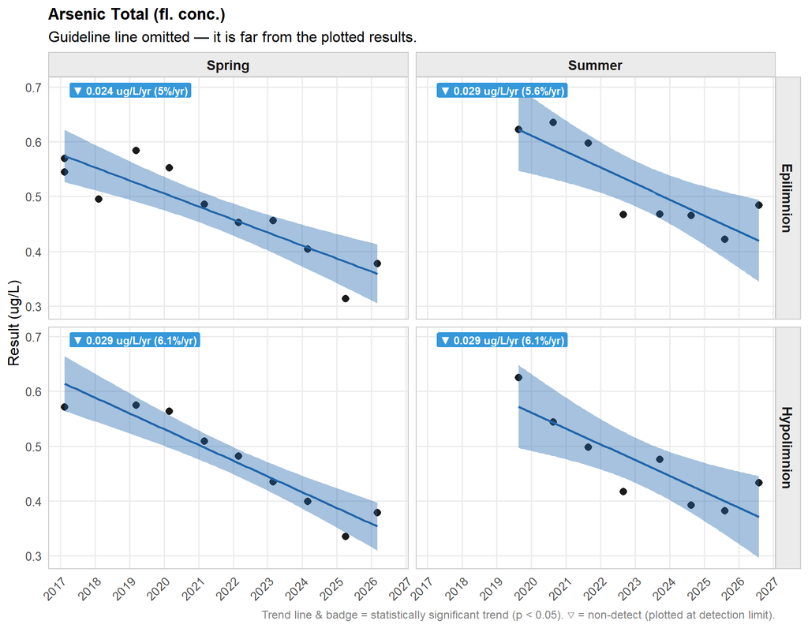

**▶ Summary Statistics Table**

**Quamichan Lake**

Arsenic Total (fl. conc.) (ug/L)

| N | Min<sup>1</sup> | 10th %ile | Median | Mean | 90th %ile | Max |
| --- | --- | --- | --- | --- | --- | --- |
| Hypolimnion — Summer |  |  |  |  |  |  |
| 8 | 0.382 | 0.389 | 0.454 | 0.471 | 0.568 | 0.625 |
| Hypolimnion — Spring |  |  |  |  |  |  |
| 9 | 0.335 | 0.37 | 0.482 | 0.472 | 0.572 | 0.575 |
| Epilimnion — Summer |  |  |  |  |  |  |
| 8 | 0.422 | 0.452 | 0.476 | 0.52 | 0.626 | 0.635 |
| Epilimnion — Spring |  |  |  |  |  |  |
| 11 | 0.314 | 0.378 | 0.486 | 0.476 | 0.569 | 0.584 |

<sup>1</sup> < indicates non-detect; value shown is the detection limit.

##### Barium Total (fl. conc.)

✓

[BC Aquatic Life Guideline](https://www2.gov.bc.ca/gov/content/environment/air-land-water/water/water-quality/water-quality-guidelines/approved-water-quality-guidelines) · Long-term chronic (Upper Limit) Aquatic Life - Freshwater

≤1 mg/L

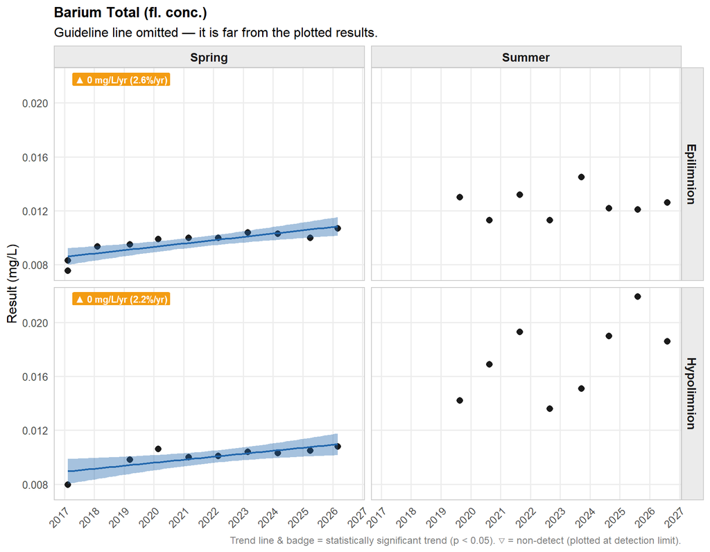

**▶ Summary Statistics Table**

**Quamichan Lake**

Barium Total (fl. conc.) (mg/L)

| N | Min<sup>1</sup> | 10th %ile | Median | Mean | 90th %ile | Max |
| --- | --- | --- | --- | --- | --- | --- |
| Hypolimnion — Summer |  |  |  |  |  |  |
| 8 | 0.0136 | 0.014 | 0.0177 | 0.0173 | 0.0201 | 0.0219 |
| Hypolimnion — Spring |  |  |  |  |  |  |
| 9 | 0.00795 | 0.00945 | 0.0103 | 0.0101 | 0.0106 | 0.0108 |
| Epilimnion — Summer |  |  |  |  |  |  |
| 8 | 0.0113 | 0.0113 | 0.0124 | 0.0125 | 0.0136 | 0.0145 |
| Epilimnion — Spring |  |  |  |  |  |  |
| 11 | 0.00755 | 0.00833 | 0.00999 | 0.00964 | 0.0104 | 0.0107 |

<sup>1</sup> < indicates non-detect; value shown is the detection limit.

##### Beryllium Total (fl. conc.)

✓

[BC Aquatic Life Guideline](https://www2.gov.bc.ca/gov/content/environment/air-land-water/water/water-quality/water-quality-guidelines/approved-water-quality-guidelines) · Long-term chronic (Upper Limit) Aquatic Life - Freshwater

≤0.13 ug/L

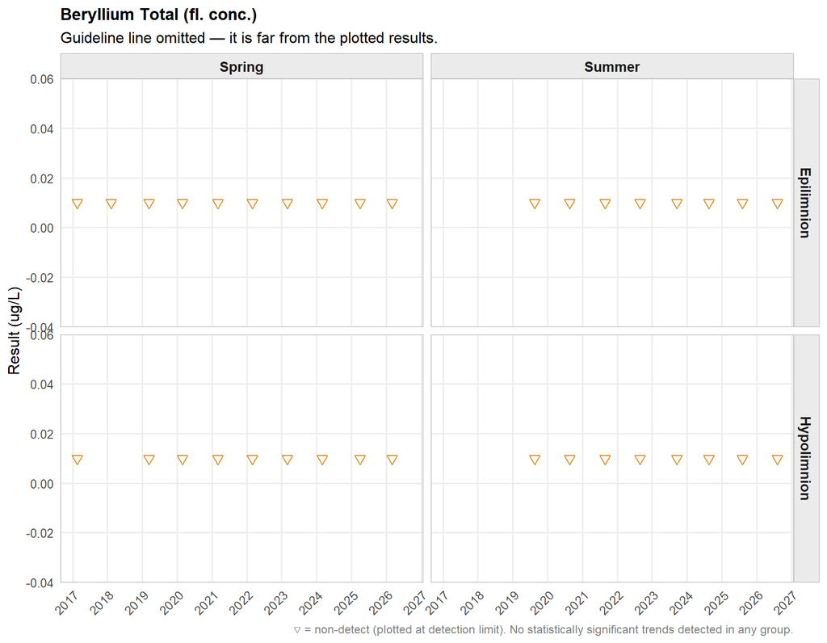

**▶ Summary Statistics Table**

**Quamichan Lake**

Beryllium Total (fl. conc.) (ug/L)

| N | Min<sup>1</sup> | 10th %ile | Median | Mean | 90th %ile | Max |
| --- | --- | --- | --- | --- | --- | --- |
| Hypolimnion — Summer |  |  |  |  |  |  |
| 8 | <0.01 | <0.01 | <0.01 | <0.01 | <0.01 | <0.01 |
| Hypolimnion — Spring |  |  |  |  |  |  |
| 9 | <0.01 | <0.01 | <0.01 | <0.01 | <0.01 | <0.01 |
| Epilimnion — Summer |  |  |  |  |  |  |
| 8 | <0.01 | <0.01 | <0.01 | <0.01 | <0.01 | <0.01 |
| Epilimnion — Spring |  |  |  |  |  |  |
| 11 | <0.01 | <0.01 | <0.01 | <0.01 | <0.01 | <0.01 |

<sup>1</sup> < indicates non-detect; value shown is the detection limit.

##### Bismuth Total (fl. conc.)

—

No simple [BC Aquatic Life Guideline](https://www2.gov.bc.ca/gov/content?id=044DD64C7E24415D83D07430964113C9) available for this parameter

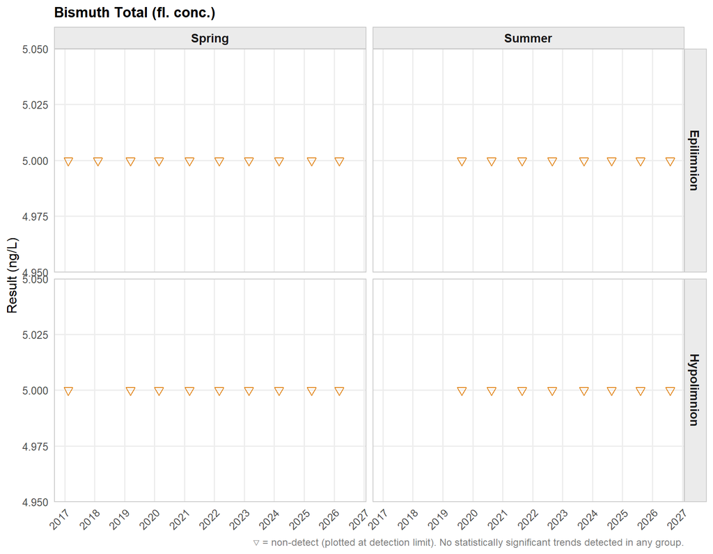

**▶ Summary Statistics Table**

**Quamichan Lake**

Bismuth Total (fl. conc.) (ng/L)

| N | Min<sup>1</sup> | 10th %ile | Median | Mean | 90th %ile | Max |
| --- | --- | --- | --- | --- | --- | --- |
| Hypolimnion — Summer |  |  |  |  |  |  |
| 8 | <5 | <5 | <5 | <5 | <5 | <5 |
| Hypolimnion — Spring |  |  |  |  |  |  |
| 9 | <5 | <5 | <5 | <5 | <5 | <5 |
| Epilimnion — Summer |  |  |  |  |  |  |
| 8 | <5 | <5 | <5 | <5 | <5 | <5 |
| Epilimnion — Spring |  |  |  |  |  |  |
| 11 | <5 | <5 | <5 | <5 | <5 | <5 |

<sup>1</sup> < indicates non-detect; value shown is the detection limit.